# Morocco Group Project Report

Farhan

27/08/2020

# Morocco Group Project: Investigating ground water salinisation and irrigation along the River Draa, Morocco

A group project by myself, Oliver Davies, Jack Field and Luke O’Driscoll.

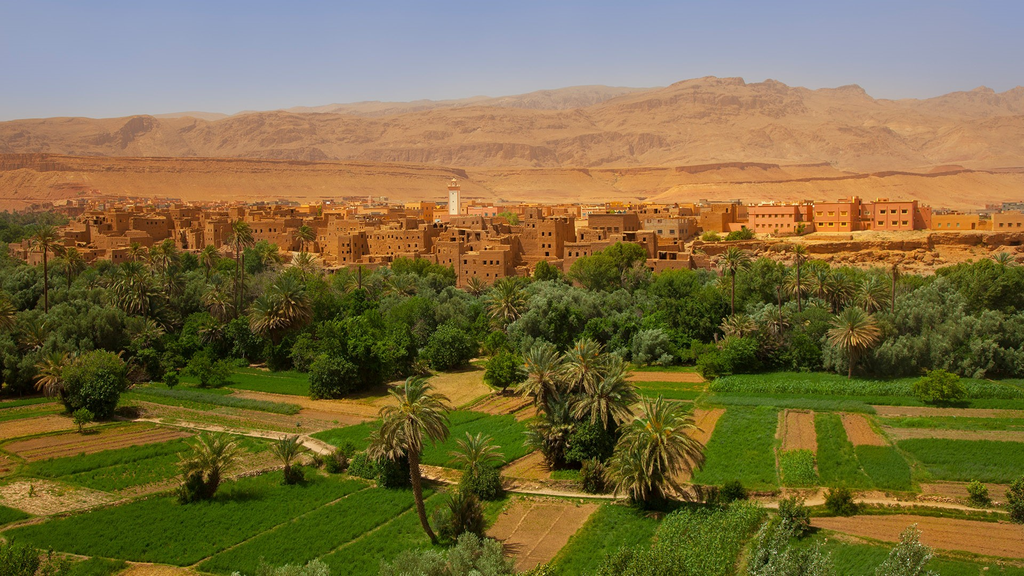

Contents:

1.0 Introduction

2.0 Methodology

2.1 Rational

2.2 Procedure

3.0 Results

3.1 Normality Tests

3.2 Correlation tests

4.0 Discussion

4.1 Results

4.2 Evaluation of Methodology

4.3 Impacts of Climate Change

5.0 Recommendations

6.0 Conclusion

7.0 List of References

### 1.0 Introduction

The salinisation of groundwater in the Drâa river basin is increasingly impacting local agricultural practices (Karroum et al.2017). A combination of primary salinisation from saline inflows derived from the High Atlas Mountains (Heidecke and Kuhn, 2007) and secondary salinisation from intensive irrigation constitutes a real threat to crop yields around Ouarzazate (Warner et al.2013). This threat will undoubtedly intensify in the near future with increase rates of evapotranspiration resulting from climate change.

The importance of maintaining non-saline groundwater for arable agriculture in the Drâa River Basin warrants an investigation into the impact of irrigation on groundwater salinity, and how this mode of secondary salinisation of groundwater in the area can be mitigated without compromising the necessary maintenance of crops in an arid landscape (Machado and Serralheiro, 2017). The investigation detailed herein evaluates the relationship between groundwater salinity and irrigation using Normalised Difference Vegetation Index (NDVI) values as a proxy for where irrigation may be occurring in the lower Drâa River valley.

### 2.0 Methodology

##### 2.1 Rationale

Where irrigation was exactly taking place in the Drâa basin could not be asserted directly due to inaccessibility and a subsequent lack of in-field observations. Instead, higher NDVI values were presumed as proxies for where more intensive irrigation and subsequent secondary salinisation was occurring (more irrigation results in higher plant abundance and health; Zheng et al.2015), thus high NDVI values were predicted to correlate with higher levels of groundwater salinity.

##### 2.2 Procedure

Correlation was used to determine the relationship between the groundwater salinity and NDVI values. Checks to assess to normality of the data revealed a non-normal distribution, preventing the use of Pearson’s correlation coefficient. Instead, Spearman’s rank correlation was chosen for this study due to its effectiveness in measuring bivariate association in non-parametric data.This statistical analysis was performed in Microsoft Excel.Figure 1 summarises the methodology.

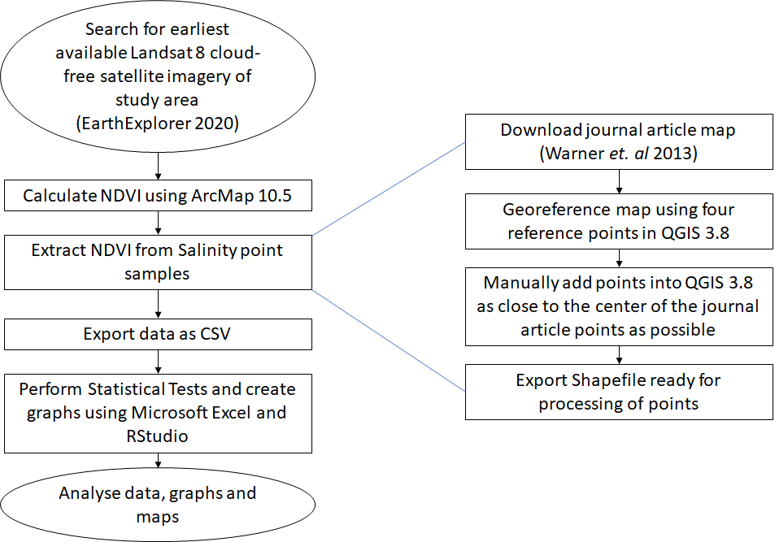

Fig.1: Methodology Framework

### 3.0 Results

Normality checks were performed using frequency histograms (Figure 2). Both the conductivity data and the NDVI values for both conductivity and NDVI exhibited strong positive newness, indicating that the data was not normally distributed.Therefore, Spearman’s rank correlation was used to assess the possible relationship between groundwater salinity(electro-conductivity readings)and vegetation health (NDVI) in order to achieve objective 1of this study.

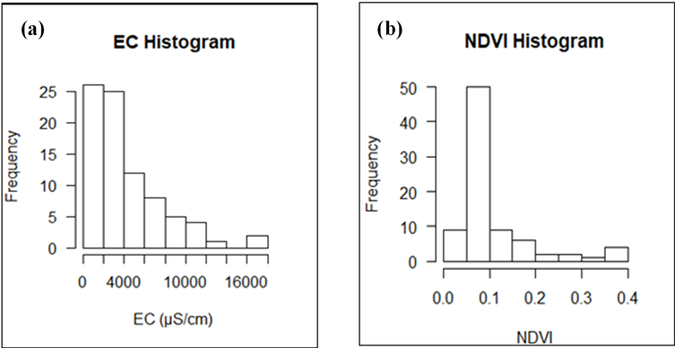

Fig. 2: Histograms indicating positive or right skewness in the electroconductivity data (a) and NDVI data (b)

##### 3.2 Correlation Output

Spearman’s rank non-parametric correlation produced a value of 0.34, suggesting a ‘weak’ (Akoglu, 2018) albeit positive relationship between the groundwater salinity and NDVI values. Figure 3 highlights the weak relationship between NDVI and EC with a large cluster below2,500mS/cm and0.1 NDVI.

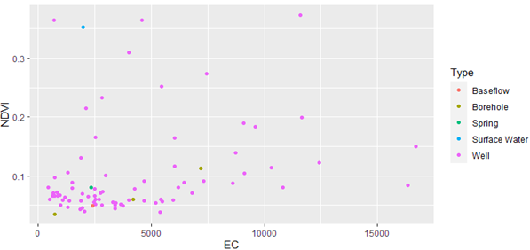

Fig. 3 : NDVI values vs Electro-conductivity measurements.

### 4.0 Discussion

##### 4.1 Results

The weak relationship determined by the correlation between groundwater salinity electro-conductivity measurements and NDVI values contradicts the presumption that irrigation is significantly increasing groundwater salinity in the lower Drâa River basin.This is particularly evident at sample point 45 (Figure 4), which lies within a high NDVI area but has a low conductivity value of 450mS/cm.This is unanticipated, considering that flows in the downstream Drâa River are used almost entirely for irrigation (Warner et al.2013). Ultimately, the weak Spearman’s rank coefficient may suggest that factors other than irrigation are determining groundwater salinity.

Boukhariet al.(2014) suggests that elevated groundwater salinity levels in the lower Drâa oases may be due to modes of primary salinisation, attributed to salts derived from the geology of the High Atlas mountains becoming suspended in flow via fluvial erosion and eventually accumulating in the unsaturated zones of the Drâa oases’ basins downstream. The large prevalence of sodium chloride derived from the High Atlas mountains observed in the Draa Valley by both Warner et al.(2013) and Boukhari et al.(2014) certainly seems to support this assertion.Furthermore, mining in the mountain range is likely accelerating this mode of primary salinisation (Brahim, 2015), disrupting the geology and releasing minerals, e.g. Ca2+, Mg2+, Na+, Cl, into nearby watercourses, which eventually accumulate downstream.

Alternatively, Warner et al.(2013) advocates that evaporation is the chief mechanism controlling groundwater salinity in the Drâa oases, observing a decrease in salinity with groundwater depth.However, some sample points indicated high groundwater salinity levels corresponding with higher NDVI values, e.g. sample point 86 had a reading of 8730mS/cm with a high NDVI, indicating that irrigation is increasing groundwater salinity to a certain extent. Certainly, irrigation is likely exacerbating the aforementioned modes of groundwater salinisation. Widespread irrigation and the recycling of pumped water from the Mansour Eddahbi reservoir, made saline from upstream inflows, has led to the dissolution of salts entrained in the Drâa River flow, allowing the salts to accumulate in groundwater basins dowsntream (Warner et al.2013). Furthermore, as water from the Drâa Rivers brought to the surface via irrigation, it evaporates, allowing salts initially in solution to precipitate and leach into groundwater basins through permeable soils via irrigation return flow (Foster et al. 2018). Thus, when the results of the Spearman’s Rank correlation are considered alongside the literature, it can be asserted that increases in groundwater salinity in the Drâa oases can be attributed to primary modes of salinisation, exacerbated by irrigation practices.

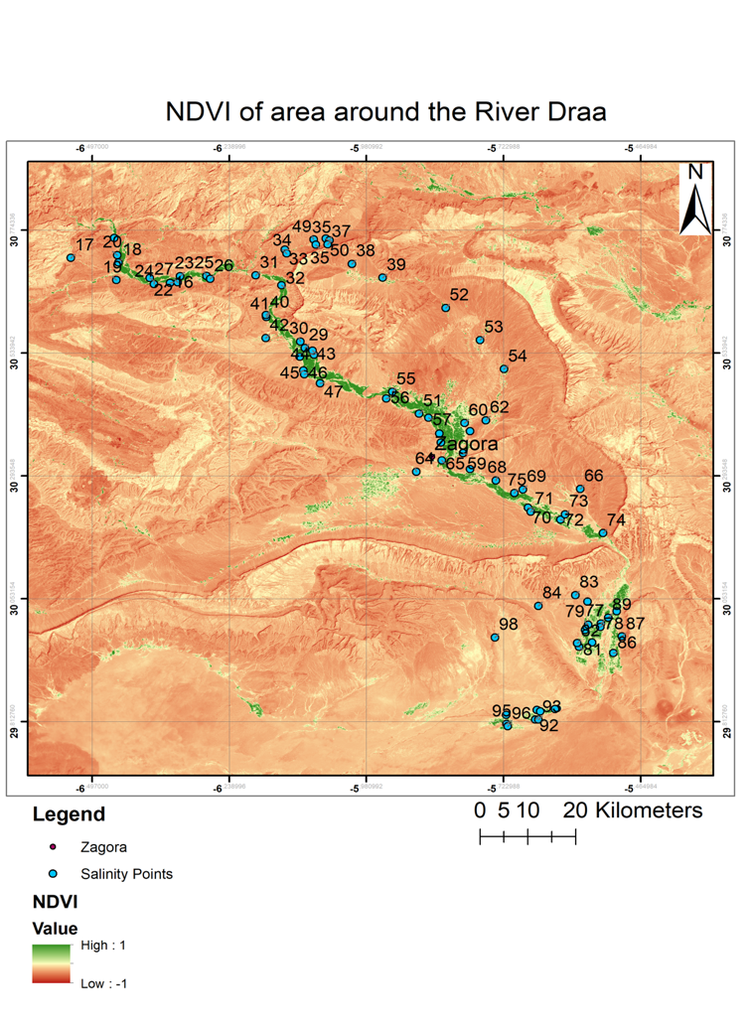

Fig. 4: NDVI map of the Drâa River with sample points.

##### 4.2 Evaluation of Methodology

The main limitation of this methodology is that high NDVI readings do not necessarily indicate exactly where irrigation is occurring. It is therefore difficult to determine whether the weak correlation between NDVI values and groundwater salinity measurements is eluding to other factors determining groundwater salinity, or whether NDVI values are not reflective of where irrigation is actually occurring. Additionally, the samples were taken during 2013 and therefore the satellite image used had to be captured at around the same time; vegetation health and groundwater salinity may well have altered in the past seven years. The map provided by the researches denoted the general area of the sample points, and thus the exact GPS coordinates were assumed.

However, due to the prevention of in-field observations, NDVI values served as the most suitable proxy for where irrigation may have been occurring, whilst care was taken to ensure the best possible accuracy of the GPS coordinates for the sample points. Furthermore, when the results of the correlation are assessed in the context of the surrounding literature, it can be confidently asserted that levels of groundwater salinity in the lower Drâa basin are controlled by several, interrelated factors, rather than just irrigation alone.

##### 4.3 Impact of Climate Change

The IPCC’s fifth assessment report assumes a rise in temperature of 2oC by 2080 under a medium emission scenario (IPCC, 2014). Additionally, although higher levels of precipitation are predicted in southern Morocco,the country is expected to experience an overall reduction in precipitation and an increase in seasonal spatial dependency on the rain that falls (Barkhordarian et al, 2013). Indeed, overall precipitation in North Africa is set to reduce between 10-20%by 2050 (Schilling et al.2012).

The IPCC report also suggests that the predicted changes under a medium emissions scenario will likely exacerbate existing stress factors on water availability and groundwater salinisation, principally due to increased rates of evapotranspiration.Increases in groundwater salinity as a result of increased evaporation rates and the subsequent dissolution of salts, as predicted by the World Bank (2014),in a country that fundamentally relies upon good quality irrigation waterfor agriculture will likely have drastic impacts unless mitigation methods are adopted, particularly in the lower Drâa basin.The situation is likely to be further exacerbated by a lack of groundwater recharge due to reduced precipitation rates (Schillinget al.2012).Food security is will probably befurther strained by increasingly common extreme weather events such as droughts and heat waves. A decline incereal crops yields due to either exceedance of heat tolerance or lack of water supply is also predicted(IPCC, 2014).

### 5.0 Recommendations

Such is the sensitivity of Morocco to climate change, coupled with its economic dependence of the agricultural industry and limited capacity to adopt change, Schillinget al.(2012) named Morocco as one of the most sensitive countries to climate change in North Africa. Thus, mitigation efforts must be effective without compromising agricultural production.

Assurance of crop yields and reductions in groundwater salinity may be achieved through the implementation of drip-irrigation techniques. Drip-irrigation uses pressurised irrigation technology to supply adequate amounts of water directly to the roots of the plants through plastic tubes, rather than spraying water over a general area typical of traditional irrigation systems. Drip-irrigation can increase crop yields with less water, and will not cause the foliar accumulation of salts that is typically observed in traditional irrigation systems (Benouniche et al.2014). Furthermore, drip irrigation is capable of maintaining constant soil water and salinity levels, controlling the rates of evapotranspiration and leaching of salts into the groundwater zone (Berrada, 2009). Drip-irrigation has been proven just as effective on small scale farms as it is on larger agricultural areas, so could benefit both subsistence and commercial farmers alike (Benouniche et al.2014). The efficiency of drip-irrigation is highlighted in the Tadla-Azilal region of central Morocco, where it has resulted in a 61% reduction in the volume of groundwater consumed whilst maintaining crop yields (WorldBank, 2020).

However, introducing drip-irrigation schemes can prove expensive; implementation of drip-irrigation has cost on average $5,737/ha to implement in Tadla, central Morocco (Berrada 2009). Introducing a small tax to commercial farmers and large companies for drip irrigation implementation should be marketed as an ‘investment’ into new sustainable irrigation that will both reduce the over-exploitation of water within the Drâa River basin and increase yields. However, caution should be taken when asking for taxes off smaller or subsistence farmers who do not earn enough money for the government to tax. Often the smaller farmers are illiterate which reduces their chances of getting a loan to pay taxes (Berrada 2009). Instead, the irrigation should be heavily or completely subsidised for subsistence and smaller scale farming operations to ensure they still have access to renewable irrigation techniques.

Moroccan agriculture is currently dominated by low value grain for cereal production (Houet al. 2015).An introduction of plants that have a high-market value but require limited amounts of water for growth, e.g. palms, shrubs and climbers would reduce water use within the Draa basin whilst also increasing revenue for farmers. Morocco is situated within a strong geographic position to export around the world with access to Europe, the east coast of the US, Russia and the rest of Africa. Exporting fruit and vegetables to these nations accounted for just 18% of the country’s total exports in 2015 (Houet al.2015).Increasing the growth and exportation of fruits, vegetables and horticultural plants would increase revenue for farmers; increased earnings can allow the modernisation of agriculture and the development of drip-irrigation and other water saving strategies in the lower Drâa basin.

On a local scale, the use of illegal wells is a key issue for authorities in the Drâa basin. Of the 17,000 wells in the region, only 2,000 have been sanctioned by the government and water removal monitored on a regularly basis (Molleet al.2019). To reduce the problem, the government should focus on identifying the locations of these illegal wells and ensure their destruction. To prevent future usage of illegal wells, there should be a focus on educating farmers so they understand the implications of their usage. Education alongside subsidies, introduction of drip-irrigation and new plants as part of a holistic approach should create a sustainable future of water use in the Drâa basin, even in the context of a changing climate.

### 6.0 Conclusion

A wide range of factors act in conjunction to determine groundwater salinisation in the oases of the lower Drâa River basin. In an area that is so heavily dependent on groundwater of sufficient quality and quantity for arable agriculture, increases in groundwater salinity have the potential to generate drastic ramifications. With a knowledge of the factors driving groundwater salinisation, efforts can be taken to combat and mitigate them, to ensure the sustainability of groundwater use and arable practices along the Drâa River valley in a changing climate.

### 7.0 Reference List

Akoglu, H. (2018) ‘User’s guide to correlation coefficients’. Turkish journal of emergency medicine 18 (3), 91 – 93 Benouniche, M., Zwarteveen, M. and Kuper, M. (2014) ‘‘Bricolage’ as Innovation: Opening the Black Box of Drip Irrigation Systems’. Irrigation and Drainage 63 (5), 651 – 658

Berrada, A. (2009) Assessment of Drip Irrigation in Morocco’ Conference Paper

Boukhari, K., Fakir, Y., Stigter, Y., Hajhouji, Y. and Boulet, G. (2015) ‘Origin of recharge and salinity and their role on management issues of a large alluvial aquifer system in the semi-arid Haouz plain, Morocco’. Environmental Earth Sciences 73 (1), 6195 – 6212

Brahim, Y.A., Benkaddour, A., Agoussine, M., Lemkademe, A.A., Al Yacoubi, L. and Bouchaou, L. (2015) ‘Origin and salinity of groundwater from interpretation of analysis data in the mining area of Oumjrane, Southeastern Morocco’. Environmental earth sciences 74 (6), 4787 – 4802

Foster, S., Pulido-Bosch, A., Vallejos, Á., Molina, L., Llop, A. and MacDonald, A.M. (2018) ‘Impact of irrigated agriculture on groundwater-recharge salinity: a major sustainability concern in semi-arid regions’. Hydrogeology Journal 26 (8), 2781 – 2791

Heidecke, C. and Kuhn. (2007) ‘Considering salinity effects on crop yields in hydroeconomic modelling- the case of a semi-arid river basin in Morocco’. WIT Transactions on Ecology and the Environment 103, 63 – 72

Hou, M., Grazia, C. and Malorgio, G. (2015) ‘Food safety standards and international supply chain organization: A case study of the Moroccan fruit and vegetable exports’. Food Control 55 (1), 190 – 199

IPCC (2014) ‘Climate Change 2014: Impacts, Adaptation, and Vulnerability. Part A: Global and Sectoral Aspects’. Contribution of Working Group II to the Fifth Assessment Report of the Intergovernmental Panel on Climate Change. Ed by. Field, C.B., V.R. Barros, D.J. Dokken, K.J. Mach, M.D. Mastrandrea, T.E. Bilir, M. Chatterjee, K.L. Ebi, Y.O. Estrada, R.C. Genova, B. Girma, E.S. Kissel, A.N. Levy, S. MacCracken, P.R. Mastrandrea, and L.L. White (eds.)]. Cambridge: Cambridge University Press, 1132

Karroum, M., Elgettafi, M., Elmandour, A., Wilske, C., Himi, M. and Casas, A. (2017) ‘Geochemical processes controlling groundwater quality under semi arid environment: a case study in central Morocco’. Science of the Total Environment 609, 1140 – 1151

Klose, S., Reichert, B. and Lahmouri, A., (2008) ‘Management options for a sustainable groundwater use in the Middle Drâa Oases under the pressure of climatic changes’. In Climatic Changes and Water Resources in the Middle East and North Africa. Ed. by Allan, R., Förstner, U. and Salomons, W. Berlin: Springer, 179 -195

Machado, R.M.A. and Serralheiro, R.P. (2017). ‘Soil salinity: effect on vegetable crop growth. Management practices to prevent and mitigate soil salinization’. Horticulturae 3 (2), 30

Molle, F., Sanches-Ibor, C. and Avella-Reus, L. (2019) Irrigation in the Mediterranean: Technologies, Institutions and Policies. New York: Springer

Schilling, J., Freier, K., Hertige, E. and Scheffran, J. (2012) ‘Climate change, vulnerability and adaptation in North Africa with focus on Morocco’. Agriculture, Ecosystems & Environment 156 (1), 12 – 26

USGS (2020) EarthExplorer. [online] available from https://earthexplorer.usgs.gov [15 February 2020]

Warner, N., Lgourna, Z., Bouchaou, L., Boutaleb, S., Tagma, T., Hsaissoune, M. and Vengosh, A. (2013) ‘Integration of geochemical and isotopic tracers for elucidating water sources and salinization of shallow aquifers in the sub-Saharan Drâa Basin, Morocco’. Applied geochemistry 34, 140 – 151

World Bank (2020) Moroccan Farmers Save Water on Irrigation and Increase Agricultural Production [online] available from < https://www.worldbank.org/en/results/2019/10/16/moroccan-farmers-save-wateron-irrigation-and-increase-agricultural-production> [20 April 2020]

World Bank (2014) Turn Down the Heat: Confronting the New Climate Normal. Washington, DC: World Bank. Zheng, B., Myint, S.W., Thenkabail, P.S. and Aggarwal, R.M. (2015) ‘A support vector machine to identify irrigated crop types using time-series Landsat NDVI data’. International Journal of Applied Earth Observation and Geoinformation 34, 103 -112